# PART-1:

# Univariate analysis:

Histogram and Boxplot of the dataset

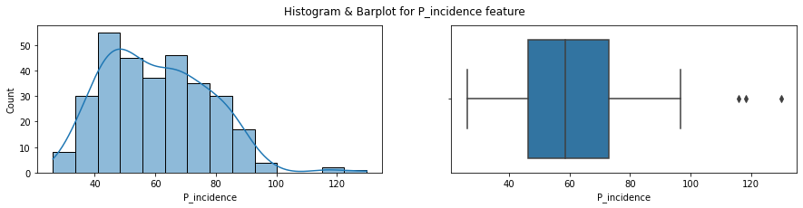

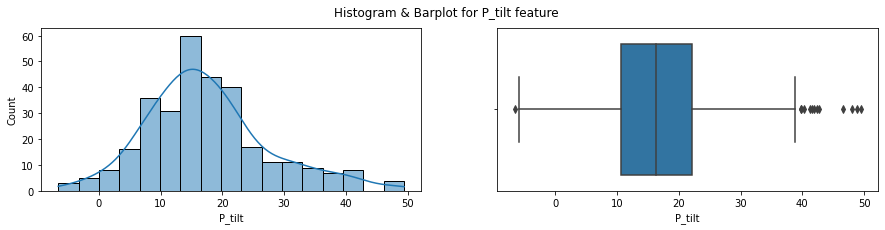

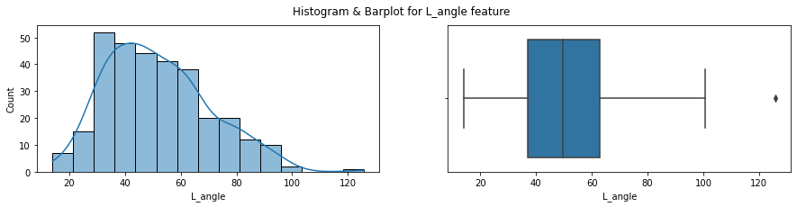

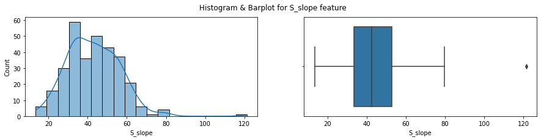

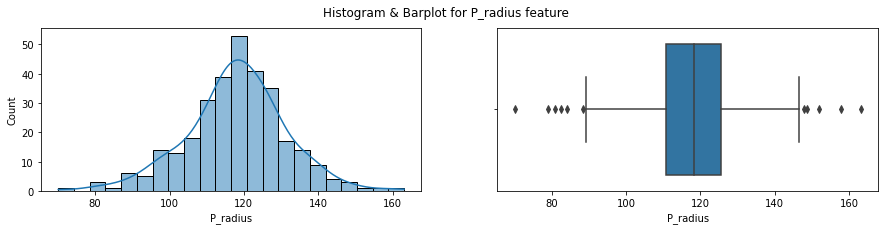

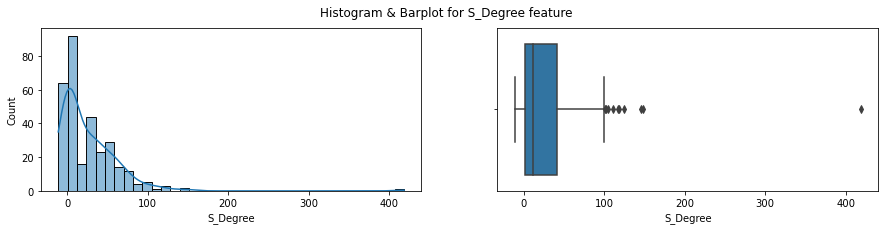

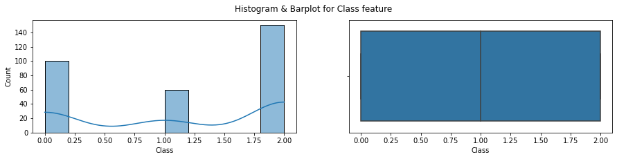

```python
nm_cols = dataset.select_dtypes(exclude='category').columns.to_list()
for i in nm_cols:
    fig,ax=plt.subplots(nrows=1, ncols=2, figsize=(15,3))
    plt.suptitle("Histogram & Barplot for {} feature".format(i), ha='center')
    sns.histplot(data=dataset,x=i,ax=ax[0],fill=True, kde=True)
    sns.boxplot(data=dataset,x=i,ax=ax[1])
```

# Comments:

P_incidence: Normality distribution is maintained and we can see three outliers in the boxplot.

P_tilt: Data is Normally distributed and we can see one peak in the center. We can see one outlier in the negative end and few outliers in positive end.

L_angle: It is Normally distributed. We can see one outlier.

S_slope: There is right skewness due to one outlier.

P_radius: Data is normally distributed. We can see outliers at both the ends.

S_Degree: There is Positive Skewness in the data. Hugely affected by Outliers.

# Barplot of target variable

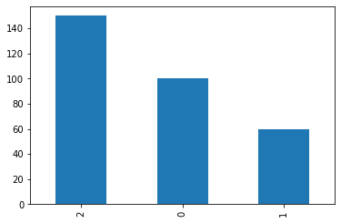

```python
pd.value_counts(dataset["Class"]).plot(kind="bar")
```

# Bi Variate Analysis:

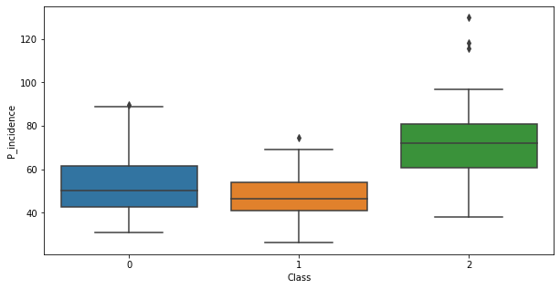

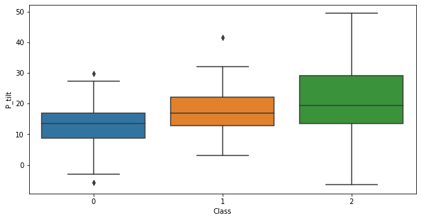

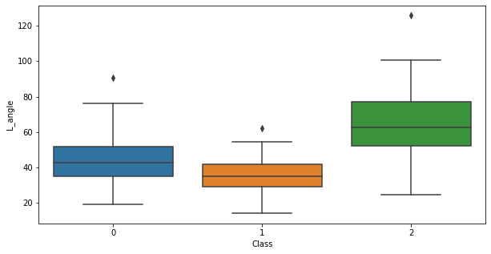

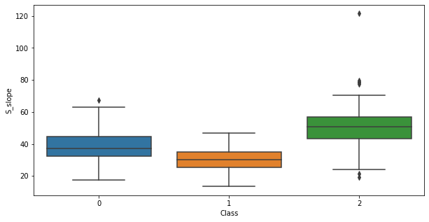

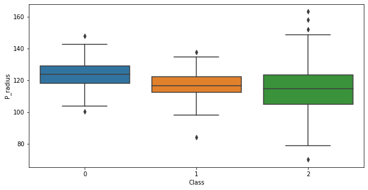

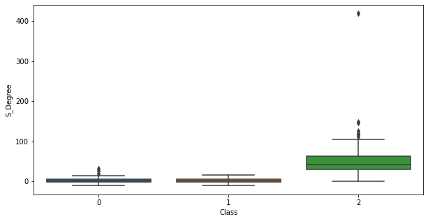

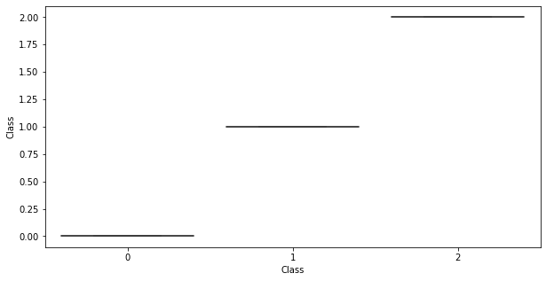

```python
num_cols = dataset.select_dtypes(exclude='category').columns.to_list()
for i in num_cols:
    plt.subplots(nrows=1, ncols=1,figsize=(10,5))
    sns.boxplot(x='Class', y=i, data= dataset)
    plt.show()
```

# Comments:

Class vs P_incidence: P_Incidence Value is larger for Type_S Class. Normal Value is slightly higher than Type_H.

Class vs P_tilt: Mean of Type_S is slightly higher than rest two. Few cases Normal and Type_H also has huge values.

Class vs L_angle: L_Angle has higher value for Type_S Class. We can see Normal class has higher values compared to type_H class.Each class contains one outlier.

Class vs S_slope: S_slope has huge values for Type_S class. Normal class has high s_slope compared to Type_H.

Class vs P_radius: We can see P_radius value is more for Normal Class. There is some extreme values for Type_s class. All classes has higher and lower Value.

Class vs S_Degree: S_Degree has extreme values for type_S Class. Few Normal class also has huge values for S_Degree.

# Multivariate Analysis

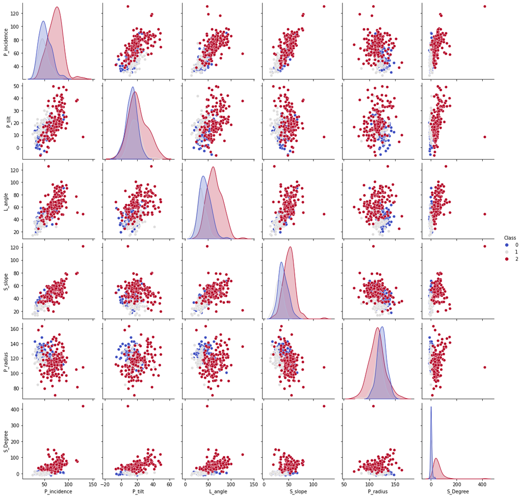

```python
sns.pairplot(dataset, diag_kind = 'kde', hue='Class', palette='coolwarm')
```

Along the diagonal we can see the distribution of individual variable

P_incidence has postive realtionship with all variables except P_radius. Relationship is higher for S_slope and L_angle

P_tilt has Higher Relationship with P_incidence and L_angle.There is no Relationship with s_slope and p_radius

L_angle has postive Relationship with p_tilt,s_slope and s_degree. It has no Relationship with P_radius

s_slope has positive Relationship with L_angle and s_degree

p_radius has no Relationship with s_degree,p_tilt,l_angle.

```python
dataset.corr() # It will show correlation matrix
```

|  | P_incidence | P_tilt | L_angle | S_slope | P_radius | S_Degree | Class |
| --- | --- | --- | --- | --- | --- | --- | --- |
| P_incidence | 1.000000 | 0.629199 | 0.717282 | 0.814960 | -0.247467 | 0.638743 | 0.537638 |
| P_tilt | 0.629199 | 1.000000 | 0.432764 | 0.062345 | 0.032668 | 0.397862 | 0.348231 |
| L_angle | 0.717282 | 0.432764 | 1.000000 | 0.598387 | -0.080344 | 0.533667 | 0.525466 |
| S_slope | 0.814960 | 0.062345 | 0.598387 | 1.000000 | -0.342128 | 0.523557 | 0.430734 |
| P_radius | -0.247467 | 0.032668 | -0.080344 | -0.342128 | 1.000000 | -0.026065 | -0.304099 |
| S_Degree | 0.638743 | 0.397862 | 0.533667 | 0.523557 | -0.026065 | 1.000000 | 0.608705 |
| Class | 0.537638 | 0.348231 | 0.525466 | 0.430734 | -0.304099 | 0.608705 | 1.000000 |

```python
# However we want to see correlation in graphical representation so below is function for that
def plot_cor(dataset, size=10):
    corr = dataset.corr()
    fig, ax = plt.subplots(figsize=(size, size))
    ax.matshow(corr)
    plt.xticks(range(len(corr.columns)), corr.columns)
    plt.yticks(range(len(corr.columns)), corr.columns)
```

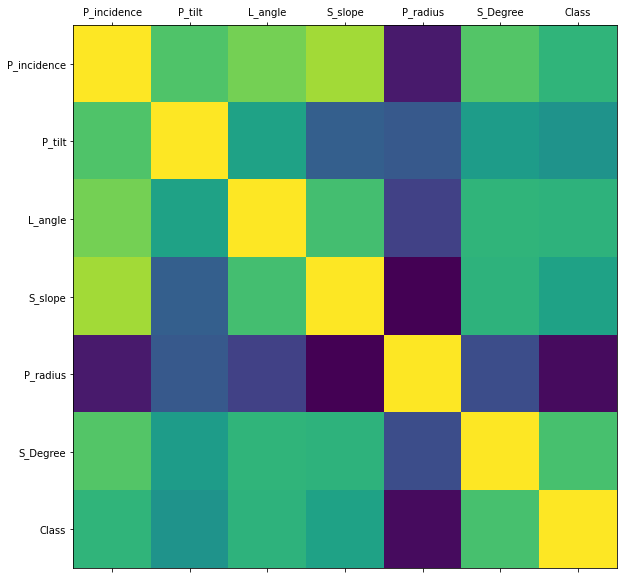

```python
plot_cor(dataset)
```

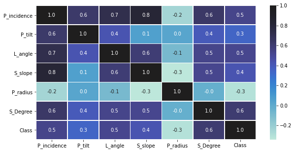

```python
#sns.heatmap(dataset.corr(),annot=True)
plt.figure(figsize=(10,5))
sns.heatmap(dataset.corr(), annot=True, linewidths=.5, fmt= '.1f', center = 1 )
plt.show()
```

# Comments:

Correlation between s_degree and p_incidence have high correlation.

S_degree and p_radius has negative correlation

# Statistical Analysis:

Statistically we can check whether all the independent variables has significant effect on target variable.

```python
# Hypothesis Testing

dataset.groupby(by=['Class']).mean()
```

| Class | P_incidence | P_tilt | L_angle | S_slope | P_radius | S_Degree |
| --- | --- | --- | --- | --- | --- | --- |
| 0 | 51.685244 | 12.821414 | 43.542605 | 38.863830 | 123.890834 | 2.186572 |
| 1 | 47.638407 | 17.398795 | 35.463524 | 30.239612 | 116.474968 | 2.480251 |
| 2 | 71.514224 | 20.748038 | 64.110108 | 50.766186 | 114.518810 | 51.896687 |

From the above data we can see there is larger mean variation in S_Degree

Hypothesis:

Null Hypothesis(Ho):There is no significant effect on independent variables with Target variable

Alternate Hypothesis(H1):There is significant effect on independent variables with Target variable

with 5% Significance level - (0.05)

```python
from scipy import stats
from scipy.stats import ttest_ind
num_cols=['P_incidence','P_tilt','L_angle','S_slope','P_radius','S_Degree']
for i in num_cols:
    ds_normal=dataset[dataset.Class=='Normal'][i]
    ds_typeH=dataset[dataset.Class=='Type_H'][i]
    ds_typeS=dataset[dataset.Class=='Type_S'][i]

    sts, p_value = ttest_ind(dataset[dataset['Class']==0][i],dataset[dataset['Class']==1][i])
    if p_value<0.05:
        print("P_value: {:.2f} , Reject Null Hypothesis: {} has impact on Class".format(p_value,i))
    else:
        print("P_value: {:.2f} , Accept Null Hypothesis: {} has no impact on Class".format(p_value,i))
```

```
P_value: 0.04 , Reject Null Hypothesis: P_incidence has impact on Class
P_value: 0.00 , Reject Null Hypothesis: P_tilt has impact on Class
P_value: 0.00 , Reject Null Hypothesis: L_angle has impact on Class
P_value: 0.00 , Reject Null Hypothesis: S_slope has impact on Class
P_value: 0.00 , Reject Null Hypothesis: P_radius has impact on Class
P_value: 0.77 , Accept Null Hypothesis: S_Degree has no impact on Class
```

Comments:

We can see Class type affects almost each and every independent variables

# 4. Data pre-processing:

• Segregate predictors vs target attributes

• Perform normalisation or scaling if required.

• Check for target balancing. Add your comments.

• Perform train-test split.

# Segregate predictors vs target attributes

```python
from sklearn.model_selection import train_test_split

# Transform data into features and target
X = dataset.drop(['Class'], axis=1)
y = dataset['Class']
```

# Perform normalisation or scaling:

```python
# convert the features into z scores as we do not know what units / scales were used and store them in new dataframe
# It is always adviced to scale numeric attributes in models that calculate distances.

from scipy.stats import zscore

XScaled  = X.apply(zscore)  # convert all attributes to Z scale

XScaled.describe().transpose()
```

|  | count | mean | std | min | 25% | 50% | 75% | max |
| --- | --- | --- | --- | --- | --- | --- | --- | --- |
| P_incidence | 310.0 | 8.702716e-17 | 1.001617 | -1.996010 | -0.817398 | -0.104925 | 0.719464 | 4.029206 |
| P_tilt | 310.0 | 2.326096e-16 | 1.001617 | -2.411664 | -0.688114 | -0.118606 | 0.458116 | 3.191402 |
| L_angle | 310.0 | 1.980495e-16 | 1.001617 | -2.047652 | -0.806027 | -0.127862 | 0.597549 | 3.984615 |
| S_slope | 310.0 | 5.121351e-17 | 1.001617 | -2.207741 | -0.716842 | -0.040960 | 0.726941 | 5.855771 |
| P_radius | 310.0 | -6.274551e-16 | 1.001617 | -3.597963 | -0.542383 | 0.026138 | 0.567621 | 3.395818 |
| S_Degree | 310.0 | -8.156558e-17 | 1.001617 | -0.996172 | -0.658507 | -0.387450 | 0.399768 | 10.460350 |

```python
XScaled.head()
```

|  | P_incidence | P_tilt | L_angle | S_slope | P_radius | S_Degree |
| --- | --- | --- | --- | --- | --- | --- |
| 0 | -1.277922 | -0.057898 | -0.907904 | -1.597803 | 0.730468 | -0.488288 |
| 1 | -0.324010 | 0.142672 | -0.017786 | -0.522437 | 0.596124 | -0.647896 |
| 2 | -0.937559 | -0.860412 | -0.271475 | -0.562386 | 0.849889 | -0.568091 |
| 3 | -0.707649 | -0.009077 | -0.212206 | -0.901920 | 0.831811 | -0.725568 |
| 4 | -0.859732 | -0.688835 | -0.504914 | -0.590377 | 0.921914 | -0.791650 |

# Check for target balancing:

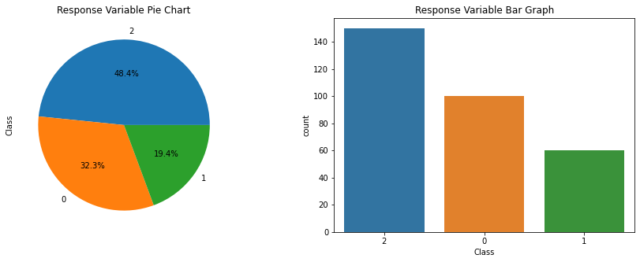

```python
f,axes=plt.subplots(1,2,figsize=(15,5))
dataset['Class'].value_counts().plot.pie(autopct='%1.1f%%',ax=axes[0])
sns.countplot('Class',data=dataset,ax=axes[1],order=[2,0,1])
axes[0].set_title('Response Variable Pie Chart')
axes[1].set_title('Response Variable Bar Graph')
plt.show()
```

# Comments:

We have imbalanced target variable. All the classes are not equally distributed. 48.4% of data is occupied by Type_S. When we have imbalanced dataset, model does not learn about less distributed classes. This gives poor performance in unseen data.

# Perform train-test split:

```python
# Split X and y into training and test set in 70:30 ratio
from sklearn.model_selection import train_test_split

X_train, X_test, y_train, y_test = train_test_split(X, y, test_size=0.30, random_state=10)
```

```python
print(X_train.shape)
print(y_train.shape)
```

```
(217, 6)
(217,)
```

```python
print(X_test.shape)
print(y_test.shape)
```

```
(93, 6)
(93,)
```

# 5. Model training, testing and tuning:

• Design and train a KNN classifier.

• Display the classification accuracies for train and test data.

• Display and explain the classification report in detail.

• Automate the task of finding best values of K for KNN.

• Apply all the possible tuning techniques to train the best model for the given data. Select the final best trained model with your comments for selecting this model.

# Design and train a KNN classifier:

```python
from sklearn.neighbors import KNeighborsClassifier
from sklearn import model_selection

KNN = KNeighborsClassifier(n_neighbors= 5)
```

```python
# Call Nearest Neighbour algorithm
KNN.fit(X_train, y_train)
```

```
KNeighborsClassifier()
```

# Evaluate Performance of kNN Model:

Let's evaluate our KNN model!

Use the predict method to predict values using your KNN model and X_test.

```python
# For every test data point, predict it's label based on 5 nearest neighbours in this model. The majority class will
# be assigned to the test data point

predicted_labels = KNN.predict(X_test)
```

# Display the classification accuracies for train and test data:

```python
print('Accuracy on Training data:',KNN.score(X_train, y_train) )
print('Accuracy on Test data:',KNN.score(X_test, y_test) )
```

```
Accuracy on Training data: 0.8940092165898618
Accuracy on Test data: 0.7741935483870968
```

Training Acuracy is 0.89 and Testing Accuracy is 0.77. Performance is less in test data.

# Display and explain the classification report in detail:

```python
from sklearn.metrics import classification_report,confusion_matrix
```

```python
print(confusion_matrix(y_test,predicted_labels))
```

```
[[16 12  0]
 [ 6 12  0]
 [ 1  2 44]]
```

Our model predicts Type_S correctly most of the time. Only three misclassification on this class

```python
print(classification_report(y_test,predicted_labels))
```

```
              precision    recall  f1-score   support

           0       0.70      0.57      0.63        28
           1       0.46      0.67      0.55        18
           2       1.00      0.94      0.97        47

    accuracy                           0.77        93
   macro avg       0.72      0.72      0.71        93
weighted avg       0.80      0.77      0.78        93
```

Precision for Normal class: It tells,out of all predicted normal class what fraction are predicted correctly

Recall(sensitivity or TPR) for Normal class: Out of all actual Normal class how much fraction we identified correctly

class 0 predicted correctly for 70% of time. similary for class 1 46% and class 2 100%

By F1 score we can say that precison and recall is balanced for class 0 by 63% and for class 1 by 55 %

We have maximum F1 score for class 2 by 97%.

# Choosing a K Value

Build the model and train and test on training and test sets respectively using scikit-learn. Print the Accuracy of the model with different values of k=3,5,9.

For accuracy you can check accuracy_score() in scikit-learn

```python
# loading library
from sklearn.neighbors import KNeighborsClassifier
from sklearn.metrics import accuracy_score

# instantiate learning model (k = 3)
knn = KNeighborsClassifier(n_neighbors = 3)

# fitting the model
knn.fit(X_train, y_train)

# predict the response
y_pred = knn.predict(X_test)

# evaluate accuracy
print('For K=3: ', accuracy_score(y_test, y_pred))

# instantiate learning model (k = 5)
knn = KNeighborsClassifier(n_neighbors=5)

# fitting the model
knn.fit(X_train, y_train)

# predict the response
y_pred = knn.predict(X_test)

# evaluate accuracy
print('For K=5: ',accuracy_score(y_test, y_pred))

# instantiate learning model (k = 9)
knn = KNeighborsClassifier(n_neighbors=9)

# fitting the model
knn.fit(X_train, y_train)

# predict the response
y_pred = knn.predict(X_test)

# evaluate accuracy
print('For K=9: ',accuracy_score(y_test, y_pred))
```

```
For K=3:  0.8064516129032258
For K=5:  0.7741935483870968
For K=9:  0.7956989247311828
```

# Cross Validation

Run the KNN with no of neighbours to be 1,3,5..19 and *Find the optimal number of neighbours from the above list using the Mis classification error

Misclassification error (MSE) = 1 - Test accuracy score. Calculated MSE for each model with neighbours = 1,3,5...19 and find the model with lowest MSE

```python
# creating odd list of K for KNN
myList = list(range(1,20))

# subsetting just the odd ones
neighbors = list(filter(lambda x: x % 2 != 0, myList))
```

```python
# empty list that will hold accuracy scores
ac_scores = []

# perform accuracy metrics for values from 1,3,5....19
for k in neighbors:
    knn = KNeighborsClassifier(n_neighbors=k)
    knn.fit(X_train, y_train)
    # predict the response
    y_pred = knn.predict(X_test)
    # evaluate accuracy
    scores = accuracy_score(y_test, y_pred)
    ac_scores.append(scores)

# changing to misclassification error
MSE = [1 - x for x in ac_scores]

# determining best k
optimal_k = neighbors[MSE.index(min(MSE))]
print("The optimal number of neighbors is %d" % optimal_k)
```

```
The optimal number of neighbors is 13
```

# Plot misclassification error vs k (with k value on X-axis) using matplotlib.

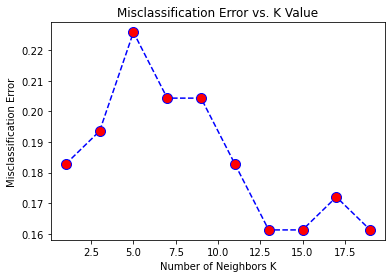

```python
import matplotlib.pyplot as plt
# plot misclassification error vs k
plt.plot(neighbors, MSE, color='blue', linestyle='dashed', marker='o',
         markerfacecolor='red', markersize=10)
plt.title('Misclassification Error vs. K Value')
plt.xlabel('Number of Neighbors K')
plt.ylabel('Misclassification Error')
plt.show()
```

# 6. Conclusion and improvisation:

• Write your conclusion on the results. • Detailed suggestions or improvements or on quality, quantity, variety, velocity, veracity etc. on the data points collected by the research team to perform a better data analysis in future.

### Retrain with new K Value

Retrain your model with the best K value (=13) and re-do the classification report and the confusion matrix.

```python
# NOW WITH K=13
KNN = KNeighborsClassifier(n_neighbors=13)

KNN.fit(X_train,y_train)
pred = KNN.predict(X_test)

print('WITH K=13')
print('\n')
print(confusion_matrix(y_test,pred))
print('\n')
print(classification_report(y_test,pred))
```

```
WITH K=13


[[19  9  0]
 [ 3 15  0]
 [ 2  1 44]]


              precision    recall  f1-score   support

           0       0.79      0.68      0.73        28
           1       0.60      0.83      0.70        18
           2       1.00      0.94      0.97        47

    accuracy                           0.84        93
   macro avg       0.80      0.82      0.80        93
weighted avg       0.86      0.84      0.84        93
```

```python
print('For K=13:')
print('Accuracy on Training data:', KNN.score(X_train, y_train))
print('Accuracy on Testing data:', KNN.score(X_test, y_test))
```

```
For K=13:
Accuracy on Training data: 0.8709677419354839
Accuracy on Testing data: 0.8387096774193549
```

For K=13 we have balanced train and test error

# PART-2:

• DOMAIN: Banking and finance • CONTEXT: A bank X is on a massive digital transformation for all its departments. Bank has a growing customer base whee majority of them are liability customers (depositors) vs borrowers (asset customers). The bank is interested in expanding the borrowers base rapidly to bring in more business via loan interests. A campaign that the bank ran in last quarter showed an average single digit conversion rate. Digital transformation being the core strength of the business strategy, marketing department wants to devise effective campaigns with better target marketing to increase the conversion ratio to double digit with same budget as per last campaign. • DATA DESCRIPTION: The data consists of the following attributes:

1. ID: Customer ID
2. Age Customer’s approximate age.
3. CustomerSince: Customer of the bank since. [unit is masked]
4. HighestSpend: Customer’s highest spend so far in one transaction. [unit is masked]
5. ZipCode: Customer’s zip code.
6. HiddenScore: A score associated to the customer which is masked by the bank as an IP.
7. MonthlyAverageSpend: Customer’s monthly average spend so far. [unit is masked]
8. Level: A level associated to the customer which is masked by the bank as an IP.
9. Mortgage: Customer’s mortgage. [unit is masked]
10. Security: Customer’s security asset with the bank. [unit is masked]
11. FixedDepositAccount: Customer’s fixed deposit account with the bank. [unit is masked]
12. InternetBanking: if the customer uses internet banking.
13. CreditCard: if the customer uses bank’s credit card.
14. LoanOnCard: if the customer has a loan on credit card.

• PROJECT OBJECTIVE: Build an AIML model to perform focused marketing by predicting the potential customers who will convert using the historical dataset. Steps and tasks: [ Total Score: 30 points ]

1. Import and warehouse data: • Import all the given datasets and explore shape and size of each. • Merge all datasets onto one and explore final shape and size.
2. Data cleansing: • Explore and if required correct the datatypes of each attribute • Explore for null values in the attributes and if required drop or impute values.
3. Data analysis & visualisation: • Perform detailed statistical analysis on the data. • Perform a detailed univariate, bivariate and multivariate analysis with appropriate detailed comments after each analysis.
4. Data pre-processing: • Segregate predictors vs target attributes • Check for target balancing and fix it if found imbalanced. • Perform train-test split.
5. Model training, testing and tuning: • Design and train a Logistic regression and Naive Bayes classifiers. • Display the classification accuracies for train and test data. • Display and explain the classification report in detail. • Apply all the possible tuning techniques to train the best model for the given data. Select the final best trained model with your comments for selecting this model.
6. Conclusion and improvisation: • Write your conclusion on the results. • Detailed suggestions or improvements or on quality, quantity, variety, velocity, veracity etc. on the data points collected by the bank to perform a better data analysis in future.

# 1. Import and warehouse data:

• Import all the given datasets and explore shape and size of each. • Merge all datasets onto one and explore final shape and size.

```python
# Importing Data file
df1 = pd.read_csv('Part2 - Data1.csv')
df1.head()
```

|  | ID | Age | CustomerSince | HighestSpend | ZipCode | HiddenScore | MonthlyAverageSpend | Level |
| --- | --- | --- | --- | --- | --- | --- | --- | --- |
| 0 | 1 | 25 | 1 | 49 | 91107 | 4 | 1.6 | 1 |
| 1 | 2 | 45 | 19 | 34 | 90089 | 3 | 1.5 | 1 |
| 2 | 3 | 39 | 15 | 11 | 94720 | 1 | 1.0 | 1 |
| 3 | 4 | 35 | 9 | 100 | 94112 | 1 | 2.7 | 2 |
| 4 | 5 | 35 | 8 | 45 | 91330 | 4 | 1.0 | 2 |

```python
df1.shape
```

```
(5000, 8)
```

```python
df1.size
```

```
40000
```

```python
df1.dtypes
```

```
ID                       int64
Age                      int64
CustomerSince            int64
HighestSpend             int64
ZipCode                  int64
HiddenScore              int64
MonthlyAverageSpend    float64
Level                    int64
dtype: object
```

```python
df2 = pd.read_csv('Part2 -Data2.csv')
df2.head()
```

|  | ID | Mortgage | Security | FixedDepositAccount | InternetBanking | CreditCard | LoanOnCard |
| --- | --- | --- | --- | --- | --- | --- | --- |
| 0 | 1 | 0 | 1 | 0 | 0 | 0 | NaN |
| 1 | 2 | 0 | 1 | 0 | 0 | 0 | NaN |
| 2 | 3 | 0 | 0 | 0 | 0 | 0 | NaN |
| 3 | 4 | 0 | 0 | 0 | 0 | 0 | NaN |
| 4 | 5 | 0 | 0 | 0 | 0 | 1 | NaN |

```python
df2.shape
```

```
(5000, 7)
```

```python
df2.size
```

```
35000
```

```python
df2.dtypes
```

```
ID                       int64
Mortgage                 int64
Security                 int64
FixedDepositAccount      int64
InternetBanking          int64
CreditCard               int64
LoanOnCard             float64
dtype: object
```

```python
df=df1.merge(df2,left_on='ID',right_on='ID') #id is common in both dataframe
df.head()
```

|  | ID | Age | CustomerSince | HighestSpend | ZipCode | HiddenScore | MonthlyAverageSpend | Level | Mortgage | Security | FixedDepositAccount | InternetBanking | CreditCard | LoanOnCard |
| --- | --- | --- | --- | --- | --- | --- | --- | --- | --- | --- | --- | --- | --- | --- |
| 0 | 1 | 25 | 1 | 49 | 91107 | 4 | 1.6 | 1 | 0 | 1 | 0 | 0 | 0 | NaN |
| 1 | 2 | 45 | 19 | 34 | 90089 | 3 | 1.5 | 1 | 0 | 1 | 0 | 0 | 0 | NaN |
| 2 | 3 | 39 | 15 | 11 | 94720 | 1 | 1.0 | 1 | 0 | 0 | 0 | 0 | 0 | NaN |
| 3 | 4 | 35 | 9 | 100 | 94112 | 1 | 2.7 | 2 | 0 | 0 | 0 | 0 | 0 | NaN |
| 4 | 5 | 35 | 8 | 45 | 91330 | 4 | 1.0 | 2 | 0 | 0 | 0 | 0 | 1 | NaN |

```python
# Dataframe row counts remains the same and the number of features increased to 14 on merging two dataframes
df.shape
```

```
(5000, 14)
```

```python
df.size
```

```
70000
```